# Prediction Assignment for Machine Learning Course

September 20, 2015

## Human Activity Recognition

Read more: http://groupware.les.inf.puc-rio.br/har#ixzz3jfosRia6

**Data**

The training data for this project are available here:

https://d396qusza40orc.cloudfront.net/predmachlearn/pml-training.csv

The test data are available here:

https://d396qusza40orc.cloudfront.net/predmachlearn/pml-testing.csv

The data for this project come from this source: http://groupware.les.inf.puc-rio.br/har. If you use the document you create for this class for any purpose please cite them as they have been very generous in allowing their data to be used for this kind of assignment.

The goal of our project is to predict the manner in which they did the exercise. This is the “classe” variable in the training set. The letter “A” stand for the correct performance and other letters represent different mistakes. We may use any of the other variables to predict with.

We can load both data files and check the data. The last column “classe” contains letters which code the performance quality. I’ll start with loading packages I need.

```r
library(caret); library(e1071);library(randomForest); library(kernlab)
training=read.csv("pml-training.csv", stringsAsFactors=F)
testing=read.csv("pml-testing.csv", stringsAsFactors=F)
dim(training)
```

```
## [1] 19622   160
```

Now we can look at both files more closely. In particular, it is easy to establish that first columns contains names of subjects, days and times of recording and other classifiers which do not represent physical movements. For example the very first “X” column is used to enumerate rows.

```r
names(training)[1:10]
```

```
##  [1] "X"                    "user_name"            "raw_timestamp_part_1"
##  [4] "raw_timestamp_part_2" "cvtd_timestamp"       "new_window"
##  [7] "num_window"           "roll_belt"            "pitch_belt"
## [10] "yaw_belt"
```

```r
training$X[1:20]
```

```
##  [1]  1  2  3  4  5  6  7  8  9 10 11 12 13 14 15 16 17 18 19 20
```

Then we have users’ names and so on. They should be removed for a predicting model.

### Cleaning data

The next step is less obvious: by checking out the “testing” data I’ve discovered a lot of empty variables which have mostly undefined values in “training” data. Usually they are read as logical with nonexistent values and some as characters. We can check the amount of numeric variables in the test set and see that the number of useful predictors is fewer than 40%.

```r
sum(sapply(testing, is.numeric))
```

```
## [1] 57
```

To maintain the data consistency I will remove non numeric variables from both sets for my work together with the first 7 columns. The new data sets with numeric predictors will be called “trai” and “test”, respectfully.

```r
prVec=sapply(testing, is.numeric)
prVec[1:7]=F
trai=training[ , prVec]
test=testing[ , prVec]
```

Now let us split the data for cross-validation.

```r
seed.set = 11
inTrain = createDataPartition(y=trai$classe, p=0.7, list=F)
workTrai=trai[inTrain,]
valdTrai=trai[-inTrain, ]
```

### Choosing predictors

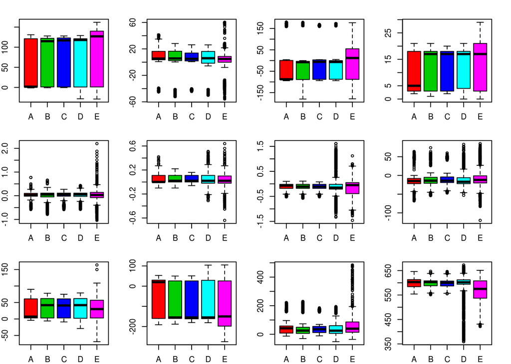

```r
par(mfrow=c(3,4), mar=c(2,2,2,2))
sapply(workTrai[, 1:12], function(x) boxplot(x~workTrai$classe, col=2:6) )
```

Let us concentrate on our goal. We need to find ways to distinguish type “A”, which is a correct way to perform, from others, which represent different mistakes. I’m going to pick up predictors for which their distributions of “A” values are notably more compact than at least one the variables and it is placed somehow higher or lower on its corresponding plot. For example, box plots on the picture in the lower right corner fits to this requirement, which corresponds to 12th predictor. Sometimes we can have problems with outliners, messing up the whole picture.

```r
numPred = names(workTrai)
numPred = numPred[-53] # Removing the "classe" variate
prefPred = rep(F, length(numPred))
classe = unique(workTrai[, "classe"])
predMed = rep(0,5)
loBnd = rep(0,5)
upBnd = rep(0,5)
medns <- data.frame(classe, predMed, loBnd, upBnd)
for (i in 1:length(numPred)) {
  for (lett in classe) {
    medBounds = quantile(workTrai[workTrai[,"classe"] == lett, i], c(.25, .5, .75))
    medns[medns[,"classe"] == lett, 2] = medBounds[2]
    medns[medns[,"classe"] == lett, 3] = medBounds[1]
    medns[medns[,"classe"] == lett, 4] = medBounds[3]
  }
  # Now I need to pick up predictors for which a median for one of performance markers
  # does not fall into a range of another marker.
  for (k in 1:length(classe)) {
    others = classe[-k]
    ind = T
    for (other in others) {
      # checking that a median is inside of other range
      ind = ind &
        ((medns[k,2] > medns[medns[,"classe"] == other, 3]) & # comparing with lower bound
           (medns[k,2] < medns[medns[,"classe"] == other, 4]))  # comparing with upper bound
    }
  }
      prefPred[i] <- prefPred[i] | (!ind)
}
```

Gathering the predictors together with “classe” column:

```r
prefVec=c(numPred[prefPred], "classe")
workdf=workTrai[ , prefVec]
workdf$classe=as.factor(workdf$classe)
```

### Random forests Algorithm

```r
 seed.set=11
library(doParallel)
cl <- makeCluster(detectCores())
registerDoParallel(cl)
modrf=train(classe~., data=workdf, method="rf")
stopCluster(cl)
```

Now we can look at the model, see its accuracy, and check how it works on my validation set. First, the model itself:

```r
modrf
```

```
## Random Forest
##
## 13737 samples
##    12 predictors
##     5 classes: 'A', 'B', 'C', 'D', 'E'
##
## No pre-processing
## Resampling: Bootstrapped (25 reps)
## Summary of sample sizes: 13737, 13737, 13737, 13737, 13737, 13737, ...
## Resampling results across tuning parameters:
##
##   mtry  Accuracy   Kappa      Accuracy SD  Kappa SD
##    2    0.9634862  0.9538049  0.003772961  0.004781184
##    7    0.9627577  0.9528930  0.003545581  0.004481723
##   12    0.9545101  0.9424614  0.003592899  0.004540698
##
## Accuracy was used to select the optimal model using  the largest value.
## The final value used for the model was mtry = 2.
```

```r
#
# Forming the testing subset of training set and computing predictions on :
valddf=valdTrai[, prefVec]
predictOnVald=predict(modrf, valddf[, -14])
```

At last, we compare predictions on the validation set:

```r
table(valdTrai$classe, predictOnVald)
```

```
##    predictOnVald
##        A    B    C    D    E
##   A 1655    3    4   12    0
##   B   14 1100   23    2    0
##   C    3    9 1011    3    0
##   D    5    2   19  937    1
##   E    1    6    7    6 1062
```

As we see on the model data and in the table, our precision is around 96%, which is quite good.

### Graduent boosting method

Now let us check another method.

```r
 seed.set=11
library(doParallel)
cl <- makeCluster(detectCores())
registerDoParallel(cl)
modgbm=train(classe~., data=workdf, method="gbm")
stopCluster(cl)
```

```r
modgbm
```

```
## Stochastic Gradient Boosting
##
## 13737 samples
##    12 predictors
##     5 classes: 'A', 'B', 'C', 'D', 'E'
##
## No pre-processing
## Resampling: Bootstrapped (25 reps)
## Summary of sample sizes: 13737, 13737, 13737, 13737, 13737, 13737, ...
## Resampling results across tuning parameters:
##
##   interaction.depth  n.trees  Accuracy   Kappa      Accuracy SD
##   1                   50      0.6420547  0.5433070  0.008107128
##   1                  100      0.6963520  0.6146012  0.006757264
##   1                  150      0.7267537  0.6536349  0.006127121
##   2                   50      0.7460415  0.6776612  0.008916402
##   2                  100      0.8131613  0.7631493  0.006729304
##   2                  150      0.8455438  0.8043729  0.005846617
##   3                   50      0.8061465  0.7541319  0.005450658
##   3                  100      0.8624284  0.8258044  0.005573443
##   3                  150      0.8883348  0.8586705  0.003818920
##   Kappa SD
##   0.010465187
##   0.008668685
##   0.007799406
##   0.011329621
##   0.008584217
##   0.007433765
##   0.006983256
##   0.007075267
##   0.004817451
##
## Tuning parameter 'shrinkage' was held constant at a value of 0.1
##
## Tuning parameter 'n.minobsinnode' was held constant at a value of 10
## Accuracy was used to select the optimal model using  the largest value.
## The final values used for the model were n.trees = 150,
##  interaction.depth = 3, shrinkage = 0.1 and n.minobsinnode = 10.
```

```r
#
# Forming the testing subset of training set and computing predictions on :
valddf=valdTrai[, prefVec]
predictOnVald=predict(modgbm, valddf[, -14])
```

we compare predictions on the validation set as well:

```r
table(valdTrai$classe, predictOnVald)
```

```
##    predictOnVald
##        A    B    C    D    E
##   A 1542   39   35   45   13
##   B   79  977   71    7    5
##   C   37   68  895   25    1
##   D   50   14   57  835    8
##   E   21   20   22   14 1005
```